# Practical Machine Learning

gmyrland

2017-12-01

# Introduction

The purpose of this report is to develop a machine learning model related to the quantified self movement. The goal is to identify the manner in which individuals performed a specific exercise – namely, lifting barbell weights either correctly incorrectly. The classifier will use data from accelerometers on the belt, forearm, arm, and dumbell of 6 participants.

```r
suppressPackageStartupMessages(library(dplyr))
knitr::opts_chunk$set(cache=TRUE)
```

# Data

The data for this project comes from `http://web.archive.org/web/20161224072740/http:/groupware.les.inf.puc-rio.br/har`. Test and training data were made available for the coursera course.

```r
# Load Data
train <- read.csv(url('https://d396qusza40orc.cloudfront.net/predmachlearn/pml-training.csv'), stringsAsFactors = FALSE)
test <- read.csv(url('https://d396qusza40orc.cloudfront.net/predmachlearn/pml-testing.csv'), stringsAsFactors = FALSE)
```

# Exploratory Analysis and Cleaning

The training dataset has 19622 rows and 160 columns, including the output column `classe`. `classe` comprises a categorical classifier with values: A, B, C, D, E.

The test dataset has 20 rows and 160 columns.

When reviewing the data, it’s clear that there are many features which have a lot of `NA` values. To simplify the dataset, we can remove features which are more than half `NA` which will likely not have high predicitve power.

```r
threshold <- 0.5
train <- train[sapply(train, function(x) mean(is.na(x)) <= threshold)]
```

We can further remove features which are not related to accelleration based on the column names.

```r
train <- train[grepl("accel|classe", names(train))]
```

This reduces the dataset to 17 features, most of which are numeric.

# Model Development

For the model, a random forest can be used. A random forest should provide fairly high accuracy without additional feature tuning. It should work fairly well “straight out of the box” for a problem like this.

The k-fold cross validation is shown below. The table provides a confusion matrix of one of the cross validation trials to show that the model is learning.

```r
suppressPackageStartupMessages(library(randomForest))
suppressPackageStartupMessages(library(caret))

folds <- createFolds(train$class, k=10)
latest_results <- NULL
accs <- NULL
for (i in 1:10) {
  idx <- folds[[i]]
  cv_train <- train[-idx, ]
  cv_test <- train[idx, ]
  fit <- randomForest(as.factor(classe) ~ ., data=cv_train)
  cv_pred <- predict(fit, cv_test, type="class")
  probs <- table(cv_pred, cv_test$classe)
  accs <- c(accs, sum(diag(probs))/sum(probs))
  latest_results <- as_data_frame(as.data.frame.matrix(probs))
}
knitr::kable(latest_results)
```

[output not shown]

The accuracies of the 10 trials are:

```r
df_acc <- data_frame(Trial=1:10, Accuracy=accs)
knitr::kable(df_acc)
```

[output not shown]

The mean accuracy from the cross validation is 0.9549483. This means the out-of-sample error rate is approximately

```r
1 - mean(accs)
```

```
## [1] 0.04505168
```

The distribution of cross validation accuracies is shown below.

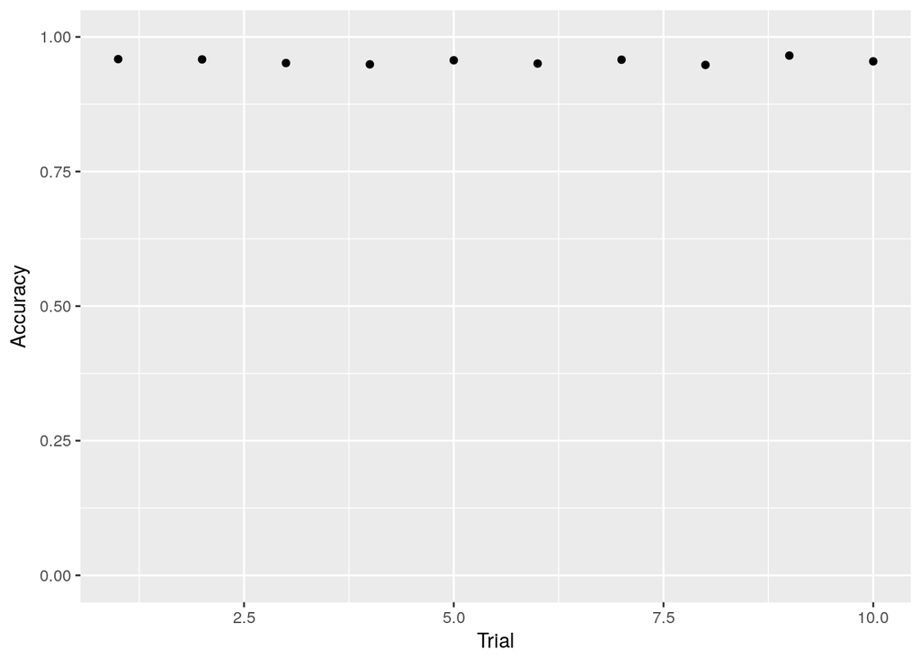

```r
library(ggplot2)
ggplot(df_acc, aes(x=Trial, y=Accuracy), fill="darkgreen") +
  geom_point() + expand_limits(y=c(0,1))
```

This is a fairly good outcome, and shows that the model is not tending to overfit. We can now train the model on the entire training set.

```r
fit <- randomForest(as.factor(classe) ~ ., data=train)
summary(fit)
```

```
##                 Length Class  Mode
## call                3  -none- call
## type                1  -none- character
## predicted       19622  factor numeric
## err.rate         3000  -none- numeric
## confusion          30  -none- numeric
## votes           98110  matrix numeric
## oob.times       19622  -none- numeric
## classes             5  -none- character
## importance         16  -none- numeric
## importanceSD        0  -none- NULL
## localImportance     0  -none- NULL
## proximity           0  -none- NULL
## ntree               1  -none- numeric
## mtry                1  -none- numeric
## forest             14  -none- list
## y               19622  factor numeric
## test                0  -none- NULL
## inbag               0  -none- NULL
## terms               3  terms  call
```

# Prediction

To test the prediction, the model which was fitted against the entire training set can be run against the test set.

```r
test <- test[names(test) %in% names(train)]
predictions <- predict(fit, test, type="class")
knitr::kable(data.frame(Prediction=predictions))
```

| Prediction |
| --- |
| B |
| A |
| C |
| A |
| A |
| E |
| D |
| B |
| A |
| A |
| B |
| C |
| B |
| A |
| E |
| E |
| A |
| B |
| B |
| B |

The predicted values were sufficient to achieve 19/20 on the quiz, which is a fairly good result.